#### Universidad Autónoma de Aguascalientes

#### Departamento: Ciencias de la Computación

#### Carrera: Ingenieria en Computación Inteligente

#### Curso: Machine Learning y Deep Learning

#### Maestro: Dr. Francisco Javier Luna Rosas

#### Alumno: Jorge Hernández

#### Semestre: Enero - Junio del 2025

## PRACTICA 5a. Curva ROC

La curva ROC grafica la Tasa de verdaderos Positivos (Sensibilidad) en el eje y contra la Tasa de Falsos Positivos (1 Especificidad) en el eje X, para diferentes umbrales de clasificación.

1). Tasa de Verdaderos Positivos (TPR o Sensibilidad): Proporción de muestras positivas correctamente clasificadas. TPR=TP/TP+FN. 2). Tasa de Falsos Positivos (FPR): Proporción de muestras negativas que fueron clasificadas erróneamente como positivas. FPR=FP / FP+TN.

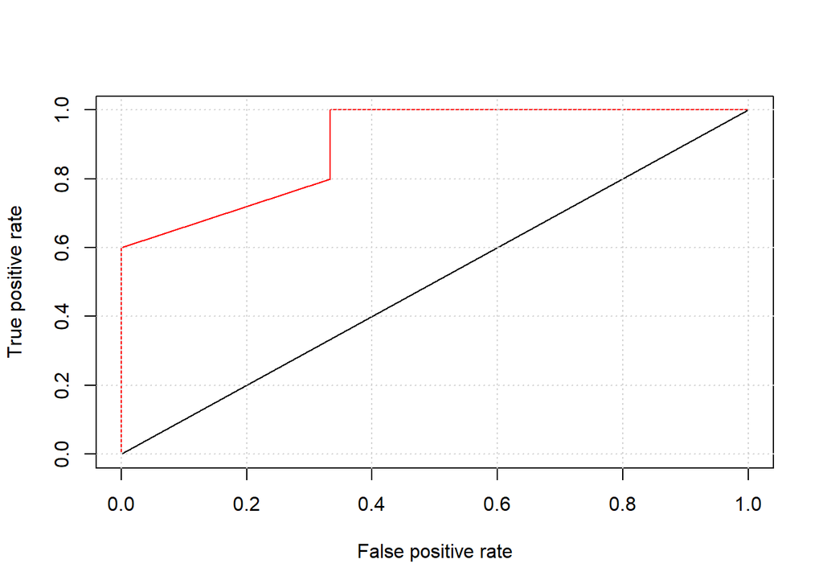

```r
library(ROCR)
pred <- prediction(
  c(0.1, 0.5, 0.3, 0.8, 0.9, 0.4, 0.9, 0.5),
  c(0, 0, 0, 1, 1, 1, 1, 1)
)
perf <- performance(pred, "tpr", "fpr")
plot(perf, col = "red")
segments(0, 0, 1, 1, col = "black")
grid()
```

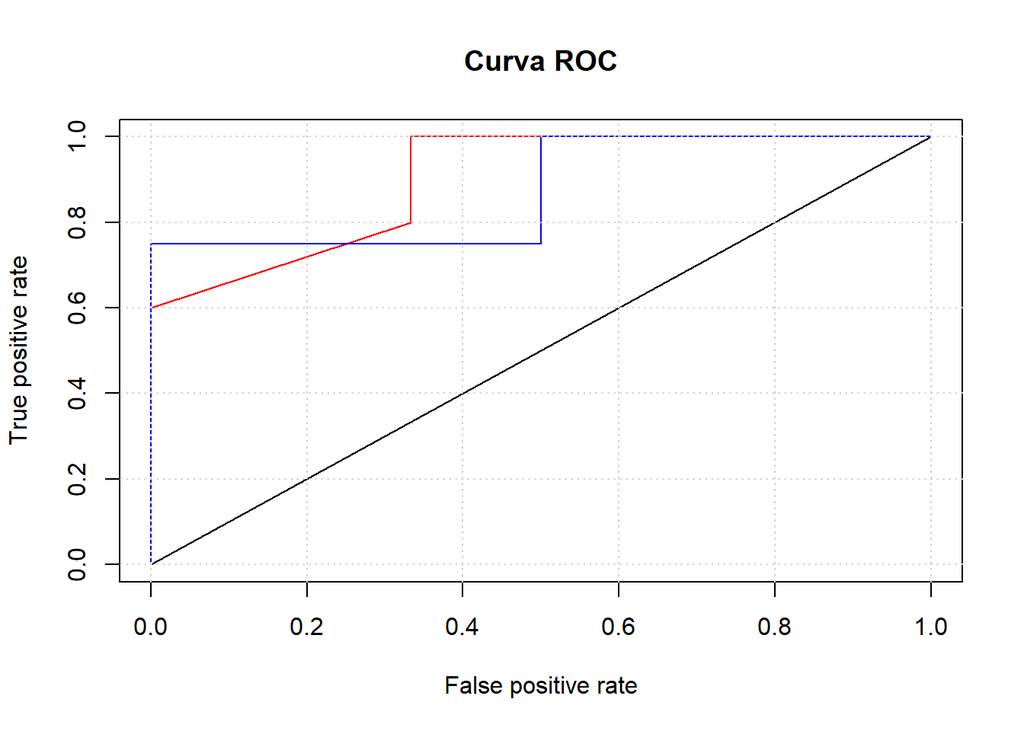

```r
library(ROCR)
plot_roc <- function(prediccion, real, adicionar = FALSE, color = "red") {
  pred <- prediction(prediccion, real)
  perf <- performance(pred, "tpr", "fpr")
  plot(perf, col = color, add = adicionar, , main = "Curva ROC")
  segments(0, 0, 1, 1, col = "#000000")
  grid()
}


score <- c(0.9, 0.9,  0.8,  0.5,  0.5,  0.4,  0.3,  0.1)
clase <- c(1, 1, 1, 0, 1, 1, 0, 0)
plot_roc(score, clase)

#### MISMO GRAFICO
score2 <- c(0.8, 0.8,  0.7,  0.5,  0.4,  0.3,  0.2,  0.1)
clase2 <- c(1, 1, 1, 0, 0, 1, 0, 0)
plot_roc(score2, clase2, adicionar = TRUE, color = "blue")
```

## Interpretación del AUC-ROC

### Un AUC alto (cercano a 1) significa que el modelo es bueno.

### Un AUC de 0.8, por ejemplo, indica que hay un 80% de probabilidad de que el modelo asigne una mayor probabilidad a una muestra positiva que a una negativa.

### Un AUC de 0.5 significa que el modelo no puede diferenciar entre clases.

#### FUNCION PARA CALCULAR EL AREA BAJO LA CURVA

```r
pred <- prediction(score, clase)
auc <- performance(pred, "auc")
attributes(auc)$y.values[[1]]
```

```
## [1] 0.9
```

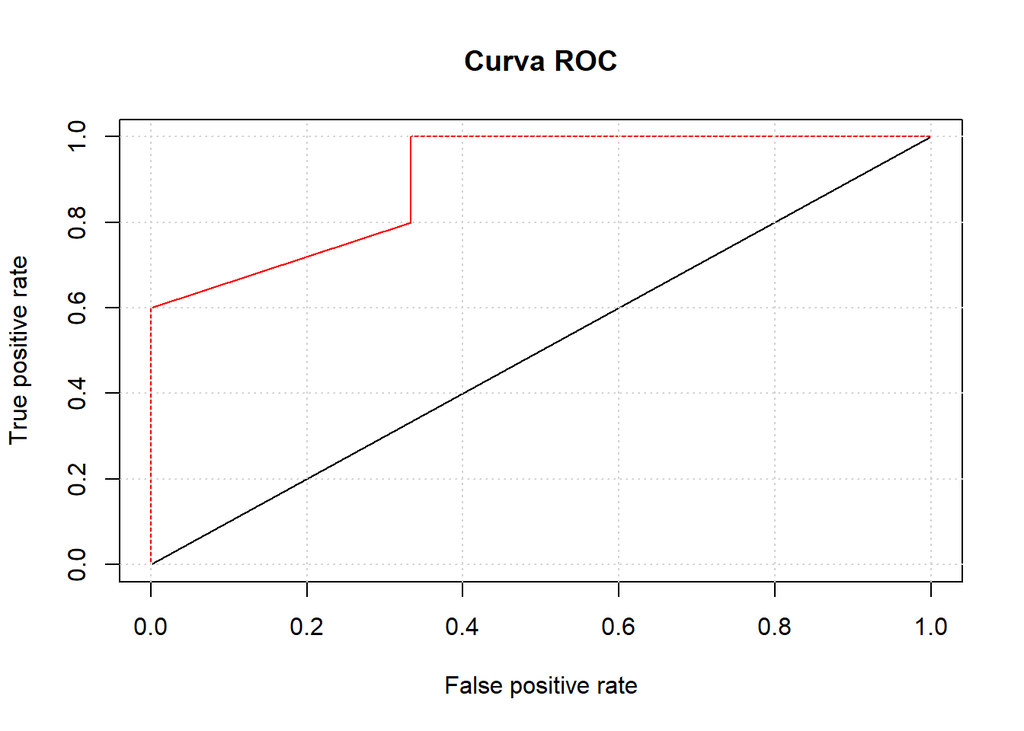

```r
area_roc <- function(prediccion, real) {
  pred <- prediction(prediccion, real)
  auc <- performance(pred, "auc")

  attributes(auc)$y.values[[1]]
}

score <- c(0.9, 0.9,  0.8,  0.5,  0.5,  0.4,  0.3,  0.1)
clase <- c(1, 1, 1, 0, 1, 1, 0, 0)
plot_roc(score, clase)
```

```r
#### MISMO GRAFICO
score2 <- c(0.8, 0.8,  0.7,  0.5,  0.4,  0.3,  0.2,  0.1)
clase2 <- c(1, 1, 1, 0, 0, 1, 0, 0)

area_roc(score, clase)
```

```
## [1] 0.9
```

```r
area_roc(score2, clase2)
```

```
## [1] 0.875
```

```r
library(e1071)
setwd("C:/Proyectos/Machine and Deep Learning/Data")
datos <- read.csv("../Data/SpamData.csv", sep = ";", dec = ".", header = TRUE)
muestra <- sample(1:4602, 1380)
ttesting <- datos[muestra, ]
taprendizaje <- datos[-muestra, ]
modelo <- naiveBayes(Tipo ~ ., data = taprendizaje)
prediccion <- predict(modelo, ttesting[, -58], type = "raw")
```

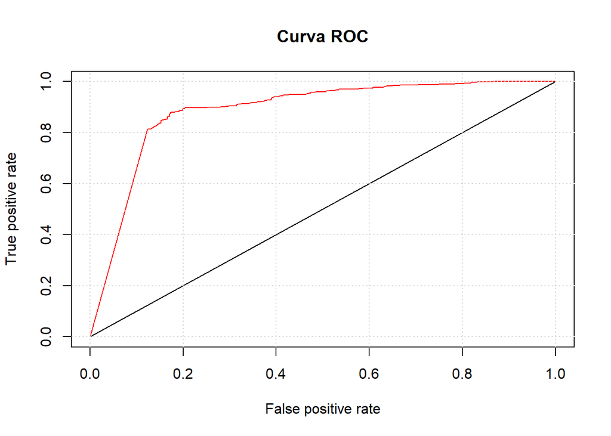

```r
score <- prediccion[, 2]
clase <- ttesting$Tipo

plot_roc(score, clase)
```

```r
area_roc <- function(prediccion, real, adicionar = FALSE, color = "red") {
  pred <- prediction(prediccion, real)
  auc <- performance(pred, "auc")
  attributes(auc)$y.values[[1]]
}

area_roc(score, clase)
```

```
## [1] 0.8864871
```

#### ARBOLES DE DECISION

```r
library(rpart)
library(rpart.plot)
setwd("C:/Proyectos/Machine and Deep Learning/Data")
datos <- read.csv("SpamData.csv", sep = ";", dec = ".", header = TRUE)
muestra <- sample(1:4602, 1380)
ttesting <- datos[muestra, ]
taprendizaje <- datos[-muestra, ]
modelo <- rpart(Tipo ~ ., data = taprendizaje)
prediccion <- predict(modelo, ttesting, type = "prob")
```

[figure not shown]

```r
score2 <- prediccion[, 2]
clase2 <- ttesting$Tipo

plot_roc(score, clase)
plot_roc(score2, clase2, adicionar = TRUE, color = "blue")

legend("bottomright",
  legend = c("Naive bayes CURVA ROC", "Rpart CURVA ROC"),
  col = c("blue", "red"), lty = 1, lwd = 1
)
```

```r
area_roc(score, clase)
```

```
## [1] 0.8864871
```

```r
area_roc(score2, clase2)
```

```
## [1] 0.8867215
```

#### REFERENCIAS

[1]John Chambers. (2008). Software for Data Analysis Programming with R. USA: Springer Verlag 2008. [2]Reporte Técnico de PROMIDAT: http://promidat.com/ (Ultimo acceso febrero 2025)